# Tutorial: Single Cell RNA-Seq Analysis of PBMC's from a healthy human Vs an Uveitis patient, using SCassist - an AI-Based Workflow Assistant

### 3.1. Analyze Variable Features

Here we ask SCassist_analyze_variable_features to explore the top 30 variable features, along with the experimental design statement and provide potential insights on the underlying system being studied.

```r
# Experimental design statement
experimental_design = "pbmcs of one healthy control and one uveitis patient"

# Ask SCassist to analyze variable features
variable_feature_analysis <- SCassist_analyze_variable_features("allsamplesgood", experimental_design = experimental_design, api_key_file = api_key_file, llm_server="google")
```

```
## The provided list of genes suggests an enrichment in pathways related to **immune response, inflammation, and leukocyte activation**.
##
## Here's a breakdown:
##
## **Immune Response & Inflammation:**
##
## * **Immunoglobulin genes (IGKC, IGLC1, IGLC2, IGHA1, IGLC3, IGHM):** These genes encode components of antibodies, crucial for adaptive immune responses. Their presence suggests activation of B cells and antibody production.
## * **Cytokines (IL1B, CCL4, CCL3, CCL4L2, CXCL8):** These genes encode signaling molecules that regulate immune cell activity and inflammation. Their presence indicates a pro-inflammatory environment.
## * **HLA genes (HLA-DRA, HLA-DRB1):** These genes encode major histocompatibility complex (MHC) proteins, crucial for antigen presentation to T cells. Their presence suggests activation of T cell responses.
## * **S100 proteins (S100A8, S100A9):** These proteins are involved in inflammation and immune cell activation. Their presence suggests a pro-inflammatory state.
## * **JCHAIN:** This gene encodes a protein essential for the assembly of multimeric immunoglobulins, further supporting antibody production.
## * **CD74:** This gene encodes a receptor for the cytokine MIF, which is involved in inflammation and immune regulation.
## * **IFIT2:** This gene encodes an interferon-induced protein involved in antiviral responses and inflammation.
##
## **Leukocyte Activation & Function:**
##
## * **GNLY:** This gene encodes a cytotoxic granule protein found in NK cells and cytotoxic T cells, suggesting activation of these cell types.
## * **PPBP:** This gene encodes a platelet factor that promotes platelet aggregation and activation.
## * **PF4:** This gene encodes a chemokine that attracts and activates platelets.
## * **GP1BB:** This gene encodes a platelet receptor involved in platelet aggregation.
## * **LYZ:** This gene encodes lysozyme, an enzyme found in neutrophils and macrophages that plays a role in bacterial killing.
## * **CST3:** This gene encodes cystatin C, a cysteine protease inhibitor involved in immune regulation.
## * **CD79A:** This gene encodes a protein involved in B cell receptor signaling, suggesting B cell activation.
##
## **Other Relevant Genes:**
##
## * **NRGN:** This gene encodes a protein involved in neuronal development, but its presence in this context could suggest potential neuro-inflammatory aspects.
## * **PTGDS:** This gene encodes a prostaglandin synthase involved in inflammation and pain.
## * **EREG:** This gene encodes a growth factor involved in wound healing and inflammation.
## * **HSPA1A:** This gene encodes a heat shock protein involved in cellular stress response.
##
## **Relevance to the Experimental Design:**
##
## The presence of these genes in PBMCs from a healthy control and a uveitis patient suggests that the patient's immune system is activated and potentially dysregulated. The specific genes involved point towards a pro-inflammatory environment with activation of both innate and adaptive immune respon…
##
## The comparison between the healthy control and the uveitis patient allows for the identification of genes that are differentially expressed in the patient, potentially providing insights into the specific mechanisms underlying the disease.
```

## 4. PCA

Here we perform PCA and ask SCassist_recommend_pcs to analzye the PCs to provide recommendation for the number of PCs to use for downstream analysis

```r
# Run PCA to generate 50 pcs
allsamplesgood <- RunPCA(object = allsamplesgood, npcs=50)

# Print genes in the top 5 pcs
print(allsamplesgood[["pca"]], dims = 1:5, nfeatures = 5)
```

```
## PC_ 1
## Positive:  S100A9, LYZ, S100A8, IL1B, HLA-DRA
## Negative:  RPS26, RPS27, RPS12, EEF1A1, RPL10
## PC_ 2
## Positive:  IGKC, IGHA1, IGLC2, IGLC1, JCHAIN
## Negative:  S100A9, S100A8, PPBP, LYZ, IL1B
## PC_ 3
## Positive:  PPBP, PF4, NRGN, GP1BB, GNG11
## Negative:  IGLC1, GNLY, IL1B, CXCL8, CCL3
## PC_ 4
## Positive:  IGKC, RPS26, HLA-DRA, CD74, RPS27
## Negative:  IGLC1, IGLC3, IGHM, PPBP, JCHAIN
## PC_ 5
## Positive:  IGLC1, HLA-DRA, IGLC3, CD74, RPS26
## Negative:  GNLY, NKG7, IGKC, GZMB, CCL4
```

### 4.1. Choosing appropriate number of PCs

Here we ask SCassist_recommend_pcs to analzye the PCs to provide recommendation for the number of PCs to use for downstream analysis

```r
pc_recommendation=SCassist_recommend_pcs("allsamplesgood", experimental_design = experimental_design, llm_server="google", api_key_file = api_key_file)
```

```
## Based on the provided variance explained by each PC, the optimal number of PCs to use for downstream analysis is **10**.
##
## Here's the reasoning:
##
## * **Elbow point:** While there isn't a super clear "elbow" in the scree plot, there's a noticeable change in the slope around PC10. The variance explained drops significantly after PC10, indicating that the subsequent PCs capture less substantial information.
## * **Variance explained:** The first 10 PCs capture approximately 65% of the total variance. This is a good balance between capturing a significant portion of the variation while avoiding excessive complexity.
## * **Balance between complexity and interpretability:** Using 10 PCs provides a reasonable level of detail without making the analysis overly complex.  Including more PCs might capture subtle variations but could lead to overfitting and difficulty in interpreting the results.
##
## Therefore, using the first 10 PCs strikes a good balance between capturing a significant portion of the variance and maintaining interpretability.
```

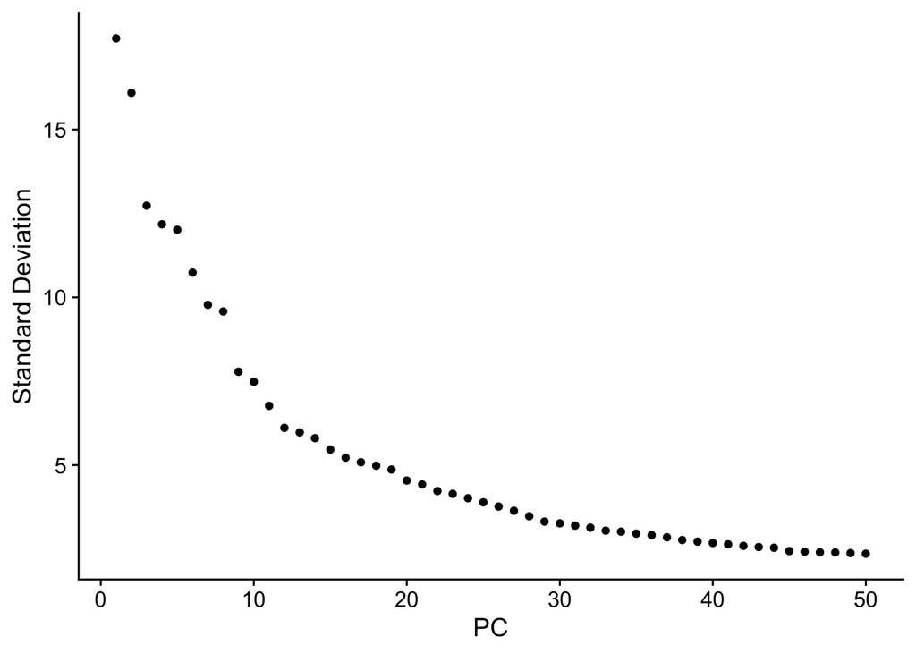

```r
# Identify number of PCs that explains majority of variations
ElbowPlot(allsamplesgood, ndims=50, reduction = "pca")
```

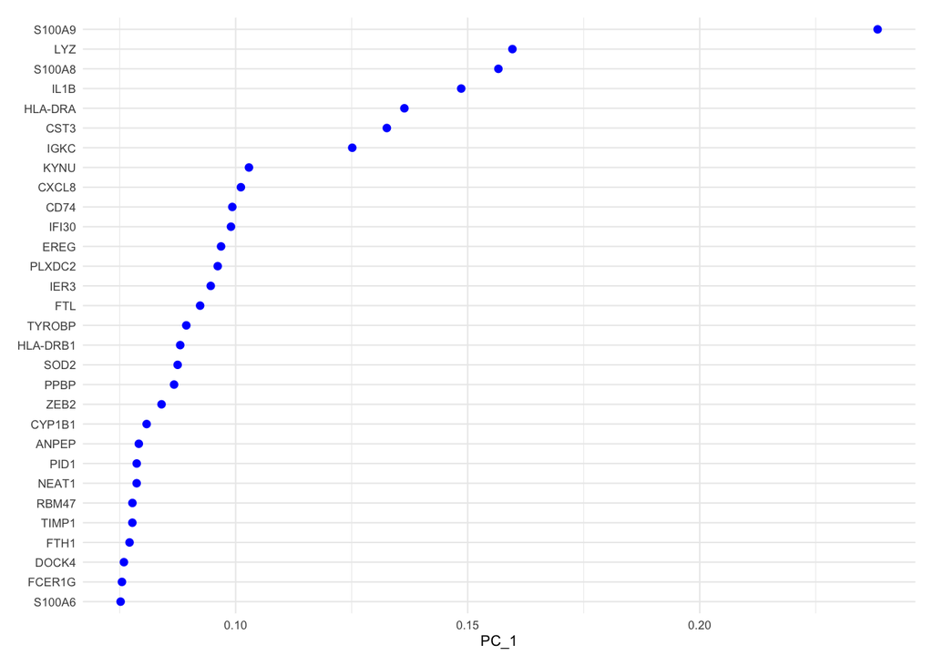

```r
# Visualize the genes in the first PC
VizDimLoadings(allsamplesgood, dims = 1, ncol = 1) + theme_minimal(base_size = 8)
```

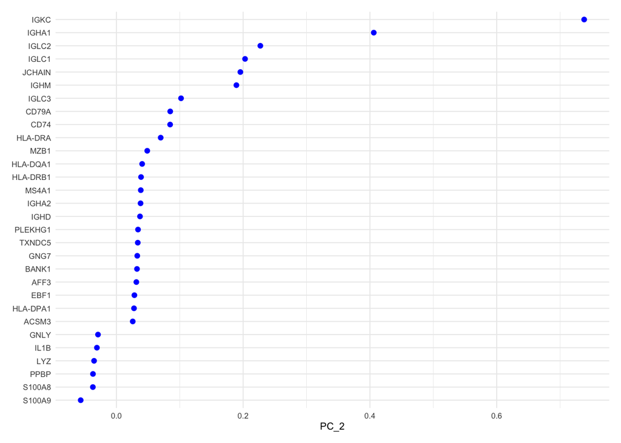

```r
# Visualize the genes in the second PC
VizDimLoadings(allsamplesgood, dims = 2, ncol = 1) + theme_minimal(base_size = 8)
```

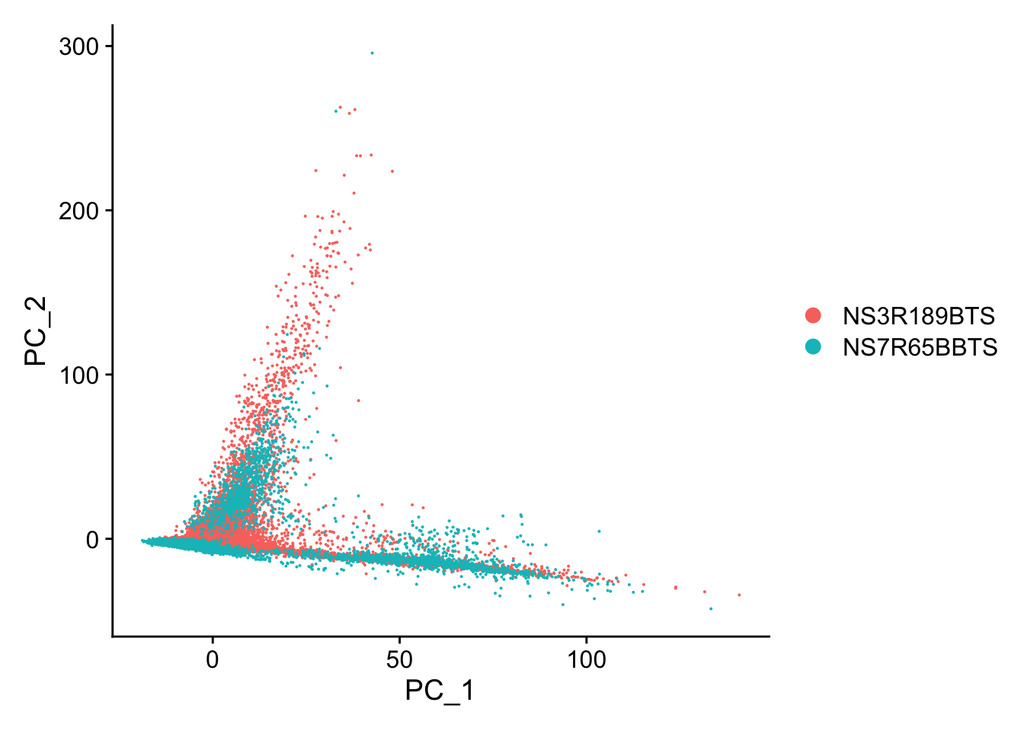

```r
# Set the identity column to  HC vs BCR-UV
Idents(allsamplesgood) <- "orig.ident"

# Visualize the cells after pca
DimPlot(object = allsamplesgood, reduction = "pca")
```

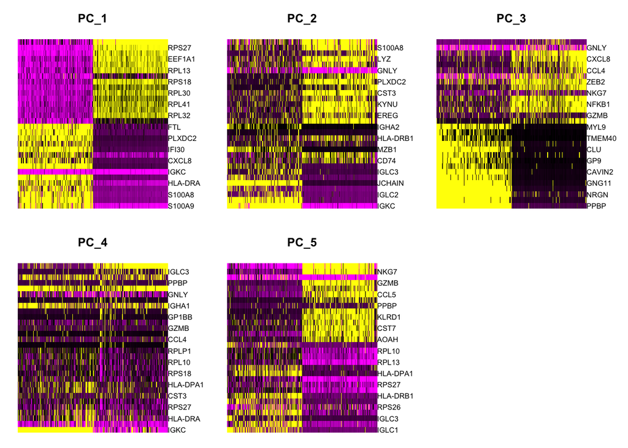

```r
# Plot heatmap with cells=500 plotting cells with extreme cells on both ends of spectrum
DimHeatmap(object = allsamplesgood, dims = 1:5, cells = 500, balanced = TRUE)
```

### 4.2. SCassist analyze PCs

```r
pc_analyzed=SCassist_analyze_pcs("allsamplesgood", num_pcs = 5, experimental_design = experimental_design, llm_server="google", api_key_file = api_key_file)
```

```
##
## **PC1 Summary:**
## The top contributing genes for PC1 are primarily associated with immune response and inflammation. Genes like S100A9, LYZ, S100A8, IL1B, HLA-DRA, CST3, CXCL8, CD74, and IFI30 are all known to be involved in the activation and recruitment of immune cells, particularly neutrophils and macrophages. …
##
##
## **PC2 Summary:**
## The top contributing genes for PC2 are primarily involved in immune response and inflammation, particularly those related to B cell activation and antibody production. Genes like IGKC, IGHA1, IGLC2, IGLC1, JCHAIN, IGHM, and CD79A are components of immunoglobulin molecules and B cell signaling pat…
##
##
## **PC3 Summary:**
## The top contributing genes for PC3 include several chemokines (CCL3, CCL4, CXCL8), inflammatory mediators (IL1B, PTGS1), and genes involved in immune cell activation and differentiation (GNLY, ITGA2B, CD9, TSPAN33). These genes are strongly associated with immune responses, particularly those rel…
##
##
## **PC4 Summary:**
## The top contributing genes for PC4 are primarily involved in immune response and cell signaling.  Genes like IGLC1, IGKC, IGHM, and JCHAIN are components of immunoglobulin production, suggesting a strong B cell signature.  Other genes like GNLY, PF4, GZMB, and NKG7 are associated with cytotoxic T…
##
##
## **PC5 Summary:**
## The top contributing genes for PC5 are primarily involved in immune response and inflammation, particularly those related to cytotoxic T lymphocytes (CTLs) and NK cells. Genes like GNLY, NKG7, GZMB, PRF1, and GZMA are known effector molecules of CTLs and NK cells, responsible for killing target c…
##
##
## ## Overall Summary of PCs:
##
## The five principal components (PCs) identified in this analysis all highlight significant variations in immune response and inflammation between healthy controls and uveitis patients.
##
## **Common Themes:**
##
## * **Immune Response:** All PCs show a strong enrichment of genes involved in immune response, particularly those related to B cell activation, antibody production, T cell activation, and cytotoxic T lymphocyte (CTL) and NK cell activity.
## * **Inflammation:**  Genes associated with inflammation, including chemokines, inflammatory mediators, and genes involved in leukocyte recruitment, are consistently present across all PCs.
##
## **Specific Contributions of Each PC:**
##
## * **PC1:**  Focuses on the activation and recruitment of immune cells, particularly neutrophils and macrophages.
## * **PC2:**  Highlights variations in B cell activation and antibody production, potentially reflecting differences in immune response related to uveitis pathogenesis.
## * **PC3:**  Captures variations in immune cell activation, inflammation, and leukocyte trafficking, suggesting differences in immune responses between groups.
## * **PC4:**  Shows a strong B cell signature, along with cytotoxic T cell activity and NK cell function, indicating variations in immune cell composition and activation state.
## * **PC5:**  Emphasizes the activation of CTLs and NK cells, and associated inflammatory processes, potentially relevant to uveitis pathogenesis.
##
## **Overall, the analysis suggests that uveitis is associated with distinct patterns of immune response and inflammation, potentially involving different immune cell populations and activation states.** Further investigation is needed to understand the specific roles of each PC in the pathogenesis …
```

## 5. FindNeighbors

Here we ask SCassist_recommend_k to identify optimum number for k, to use with FindNeighbors function, given the number of pcs we are going to use for the downstream analysis.

```r
# Run SCassist_recommend_k
recommended_k <- SCassist_recommend_k("allsamplesgood", num_pcs = 10, llm_server="google", api_key_file = api_key_file)
```

```
## ## Recommended K: 10-50
##
## ## Reasoning:
##
## The `k.param` value in `FindNeighbors()` determines the number of nearest neighbors considered for each cell when constructing the k-nearest neighbor graph. This graph is then used for clustering. A higher `k.param` value leads to a more connected graph, potentially merging distinct populations. …
##
## Given your dataset size of 34,967 cells and the use of 10 principal components, a range of `k.param` values between 10 and 50 is recommended. This range allows for exploration of different levels of connectivity while considering the dimensionality of your data. Starting with a lower value like 1…
```

```r
# Run findneighbors, with above identified pcs and k
allsamplesgood <- FindNeighbors(allsamplesgood, dims = 1:10, k.param = 30, return.neighbor = TRUE)
```

## 6. Clustering

Here we ask SCassist_recommend_res to analyze the number of cells, number of genes, mean expression variability and median neighbor distance, and recommend appropriate cluster resolutions.

```r
# Run SCassist_recommend_res
recommended_res <- SCassist_recommend_res("allsamplesgood", llm_server="google", api_key_file = api_key_file)
```

```
## Based on the data characteristics, I recommend:
##
## **Recommended Resolution:** seq(0.2, 1.2, 0.1)
##
## **Reasoning:**
##
## The mean expression variability of 0.868717336264306 suggests a moderate level of heterogeneity in your dataset. This indicates that there are likely distinct cell populations, but they may not be drastically different from each other. The median neighbor distance of 2.50502443313599 in the k-nea…
##
## Therefore, a resolution range of 0.2 to 1.2 with increments of 0.1 is recommended. This range allows for the identification of both distinct and subtle cell populations. Lower resolutions (closer to 0.2) will capture broader, more general cell types, while higher resolutions (closer to 1.2) will …
```

```r
allsamplesgood <- FindNeighbors(allsamplesgood, dims = 1:10, k.param = 30)

# Perform clustering using the SCassist recommended resolution
allsamplesgood <- FindClusters(allsamplesgood, resolution = seq(0.2,1.2,0.1))
```

```
## Modularity Optimizer version 1.3.0 by Ludo Waltman and Nees Jan van Eck
##
## Number of nodes: 34967
## Number of edges: 1730396
##
## Running Louvain algorithm...
## Maximum modularity in 10 random starts: 0.9408
## Number of communities: 10
## Elapsed time: 8 seconds
## Modularity Optimizer version 1.3.0 by Ludo Waltman and Nees Jan van Eck
##
## Number of nodes: 34967
## Number of edges: 1730396
##
## Running Louvain algorithm...
## Maximum modularity in 10 random starts: 0.9242
## Number of communities: 12
## Elapsed time: 10 seconds
## Modularity Optimizer version 1.3.0 by Ludo Waltman and Nees Jan van Eck
##
## Number of nodes: 34967
## Number of edges: 1730396
##
## Running Louvain algorithm...
## Maximum modularity in 10 random starts: 0.9123
## Number of communities: 13
## Elapsed time: 8 seconds
## Modularity Optimizer version 1.3.0 by Ludo Waltman and Nees Jan van Eck
##
## Number of nodes: 34967
## Number of edges: 1730396
##
## Running Louvain algorithm...
## Maximum modularity in 10 random starts: 0.9039
## Number of communities: 15
## Elapsed time: 8 seconds
## Modularity Optimizer version 1.3.0 by Ludo Waltman and Nees Jan van Eck
##
## Number of nodes: 34967
## Number of edges: 1730396
```

[output cut: 44 more lines]

```
## Number of edges: 1730396
##
## Running Louvain algorithm...
## Maximum modularity in 10 random starts: 0.8667
## Number of communities: 25
## Elapsed time: 7 seconds
## Modularity Optimizer version 1.3.0 by Ludo Waltman and Nees Jan van Eck
##
## Number of nodes: 34967
## Number of edges: 1730396
##
## Running Louvain algorithm...
## Maximum modularity in 10 random starts: 0.8610
## Number of communities: 28
## Elapsed time: 7 seconds
```

```r
head(allsamplesgood)
```

```
##                             orig.ident nCount_RNA nFeature_RNA percent.mito
## AAACCCACAAGTCATC-NS3R189BTS NS3R189BTS       2431         1431    4.1135335
## AAACCCACACTGGAAG-NS3R189BTS NS3R189BTS       2676         1078    0.8221226
## AAACCCACAGCACACC-NS3R189BTS NS3R189BTS       3394         1760    5.1856217
## AAACCCACAGGAGGAG-NS3R189BTS NS3R189BTS       2160         1279    6.5277778
## AAACCCACATGACGTT-NS3R189BTS NS3R189BTS       2329         1271    4.3795620
## AAACCCAGTAGTTACC-NS3R189BTS NS3R189BTS       5362         2261    3.8418501
## AAACCCAGTCCAAATC-NS3R189BTS NS3R189BTS       7926         2660    4.6177139
## AAACCCAGTCCATACA-NS3R189BTS NS3R189BTS       2239         1283    5.0468959
## AAACCCAGTGAGTTTC-NS3R189BTS NS3R189BTS       2339         1291    5.3014109
## AAACCCAGTTCTTAGG-NS3R189BTS NS3R189BTS       3537         1608    2.2900763
##                             percent.ribo percent.hb type nCount_SCT
## AAACCCACAAGTCATC-NS3R189BTS    18.510901 0.00000000   HC       2476
## AAACCCACACTGGAAG-NS3R189BTS    42.526158 0.00000000   HC       2660
## AAACCCACAGCACACC-NS3R189BTS    19.151444 0.00000000   HC       3016
## AAACCCACAGGAGGAG-NS3R189BTS     8.842593 0.00000000   HC       2321
## AAACCCACATGACGTT-NS3R189BTS    18.978102 0.04293688   HC       2431
## AAACCCAGTAGTTACC-NS3R189BTS    18.985453 0.01864976   HC       3350
## AAACCCAGTCCAAATC-NS3R189BTS    30.052990 0.02523341   HC       2781
## AAACCCAGTCCATACA-NS3R189BTS    19.830281 0.04466280   HC       2379
## AAACCCAGTGAGTTTC-NS3R189BTS    21.675930 0.00000000   HC       2440
## AAACCCAGTTCTTAGG-NS3R189BTS    23.353124 0.00000000   HC       3036
##                             nFeature_SCT SCT_snn_res.0.2 SCT_snn_res.0.3
## AAACCCACAAGTCATC-NS3R189BTS         1429               0               0
## AAACCCACACTGGAAG-NS3R189BTS         1078               1               6
## AAACCCACAGCACACC-NS3R189BTS         1758               0               0
## AAACCCACAGGAGGAG-NS3R189BTS         1278               3               3
## AAACCCACATGACGTT-NS3R189BTS         1271               6               8
## AAACCCAGTAGTTACC-NS3R189BTS         2104               4               4
## AAACCCAGTCCAAATC-NS3R189BTS         1373               2               5
## AAACCCAGTCCATACA-NS3R189BTS         1283               0               0
## AAACCCAGTGAGTTTC-NS3R189BTS         1291               0               0
## AAACCCAGTTCTTAGG-NS3R189BTS         1608               2               5
##                             SCT_snn_res.0.4 SCT_snn_res.0.5 SCT_snn_res.0.6
## AAACCCACAAGTCATC-NS3R189BTS               0               0               0
## AAACCCACACTGGAAG-NS3R189BTS               2               2               1
## AAACCCACAGCACACC-NS3R189BTS               0               0               0
## AAACCCACAGGAGGAG-NS3R189BTS               6               4               4
## AAACCCACATGACGTT-NS3R189BTS               9              11              13
## AAACCCAGTAGTTACC-NS3R189BTS               5               6               7
```

[output cut: 22 more lines]

```
## AAACCCAGTCCAAATC-NS3R189BTS             5              17              16
## AAACCCAGTCCATACA-NS3R189BTS             0               6               2
## AAACCCAGTGAGTTTC-NS3R189BTS            12               6               2
## AAACCCAGTTCTTAGG-NS3R189BTS             5              17              16
##                             seurat_clusters
## AAACCCACAAGTCATC-NS3R189BTS               3
## AAACCCACACTGGAAG-NS3R189BTS               4
## AAACCCACAGCACACC-NS3R189BTS               3
## AAACCCACAGGAGGAG-NS3R189BTS              19
## AAACCCACATGACGTT-NS3R189BTS              17
## AAACCCAGTAGTTACC-NS3R189BTS              21
## AAACCCAGTCCAAATC-NS3R189BTS              16
## AAACCCAGTCCATACA-NS3R189BTS               2
## AAACCCAGTGAGTTTC-NS3R189BTS               2
## AAACCCAGTTCTTAGG-NS3R189BTS              16
```

```r
# Count number of clusters at each resolution
sapply(grep("res",colnames(allsamplesgood@meta.data),value = TRUE),
       function(x) length(unique(allsamplesgood@meta.data[,x])))
```

```
## SCT_snn_res.0.2 SCT_snn_res.0.3 SCT_snn_res.0.4 SCT_snn_res.0.5 SCT_snn_res.0.6
##              10              12              13              15              17
## SCT_snn_res.0.7 SCT_snn_res.0.8 SCT_snn_res.0.9   SCT_snn_res.1 SCT_snn_res.1.1
##              17              20              21              23              25
## SCT_snn_res.1.2
##              28
```

```r
# change default identity
Idents(allsamplesgood) <- "SCT_snn_res.0.5"

# list cell number in each cluster for HC vs UV
table(Idents(allsamplesgood),allsamplesgood$type)
```

```
##
##      BCR-UV   HC
##   0      58 6404
##   1    3953  433
##   2     481 3506
##   3    3029   29
##   4    1467 1333
##   5     521 2193
##   6     887 1710
##   7      17 2129
##   8     890  885
##   9      43 1308
##   10   1020   68
##   11      3  923
##   12      9  817
##   13    389   84
##   14      5  373
```

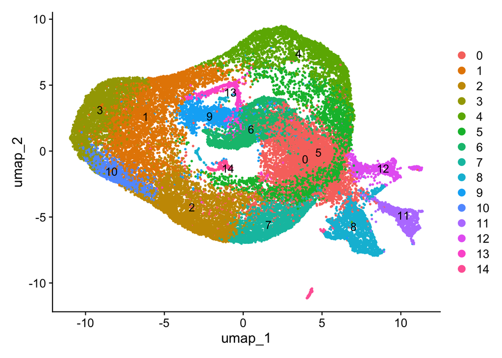

```r
# Run UMAP with identified dimensions
allsamplesgood <- RunUMAP(allsamplesgood, dims = 1:10)

# Plot umap
DimPlot(object = allsamplesgood, pt.size=0.5, reduction = "umap", label = T)
```

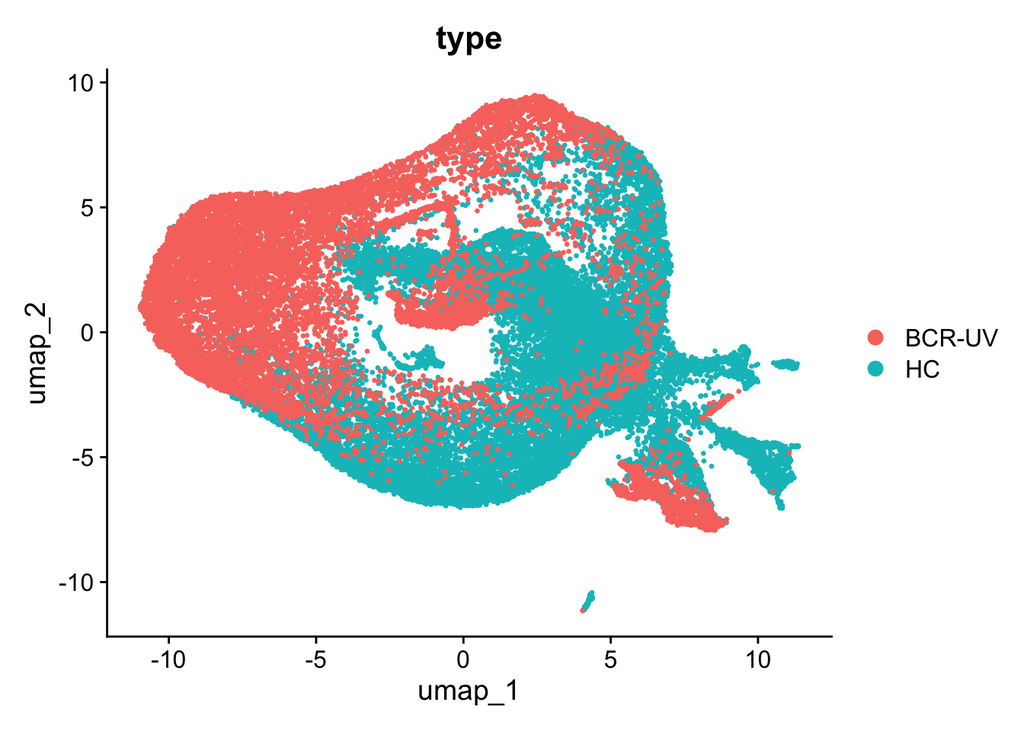

```r
# Color by HC vs BCR-UV
DimPlot(object = allsamplesgood, pt.size=0.5, reduction = "umap", group.by = "type")
```

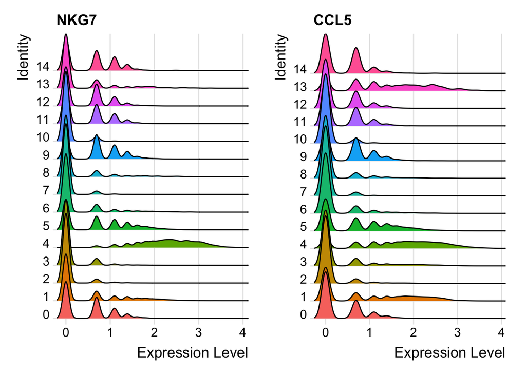

```r
# Plot umap
dimplot1<-DimPlot(object = allsamplesgood, pt.size=0.5, reduction = "umap", label = T)

# Color by HC vs BCR-UV
dimplot2<-DimPlot(object = allsamplesgood, pt.size=0.5, reduction = "umap", group.by = "type")

# Save umaps
ggsave(paste(outputpath,"umap-clusters.pdf",sep=""), plot = dimplot1, width = 20, height = 15, units = "cm")
ggsave(paste(outputpath,"umap-clusters-type.pdf",sep=""), plot = dimplot2, width = 20, height = 15, units = "cm")

# Custom list of genes to visualize
mygenes = c("NKG7","CCL5")
RidgePlot(allsamplesgood, features = mygenes)
```

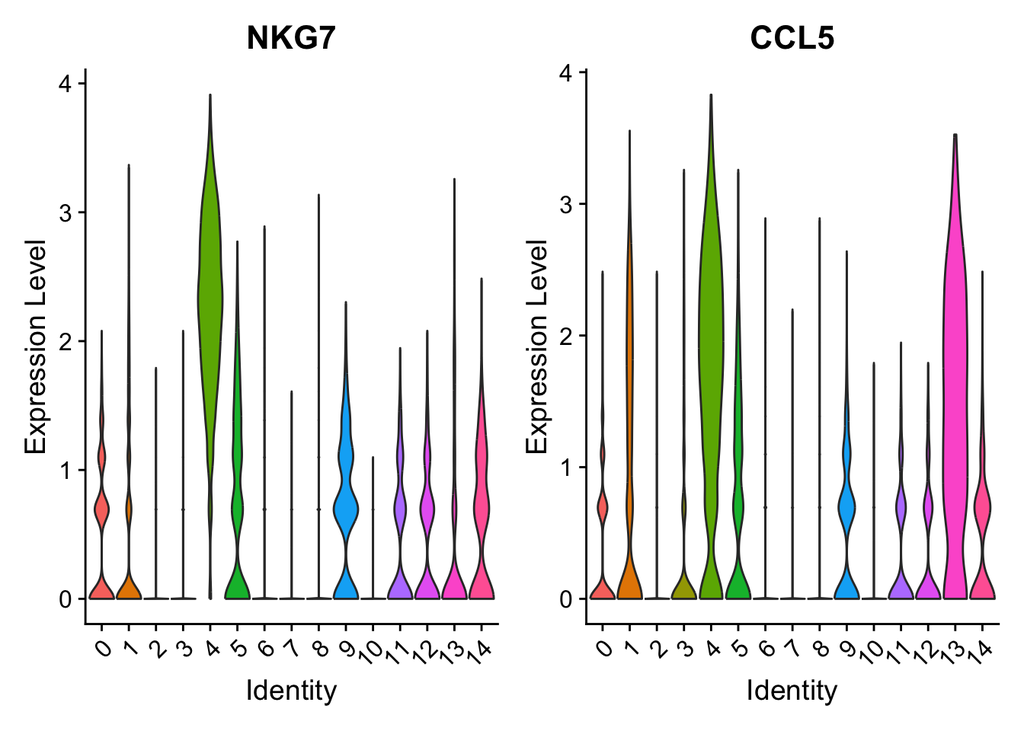

```r
VlnPlot(allsamplesgood, features = mygenes, pt.size=0)
```

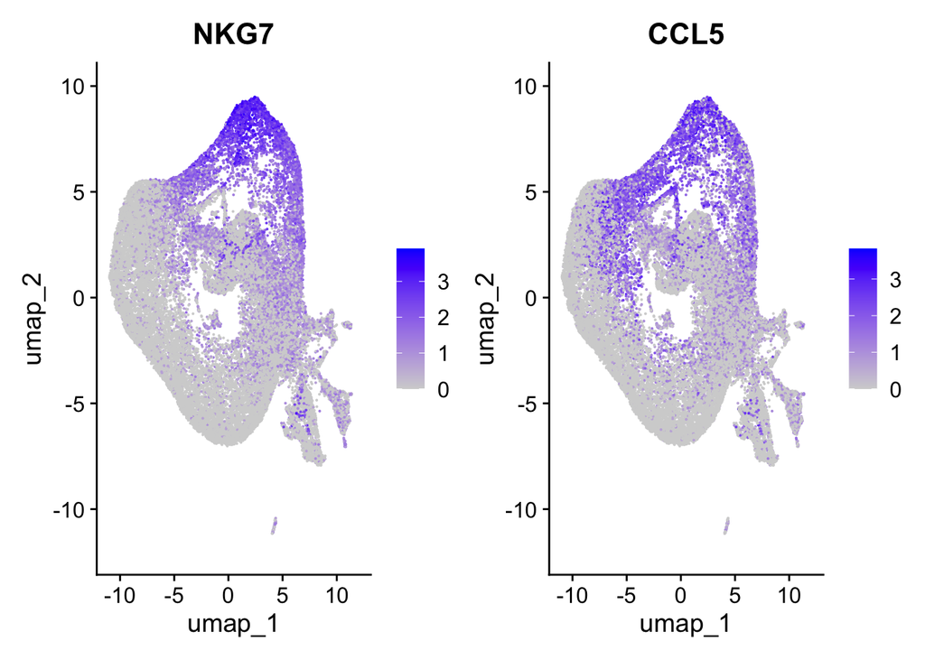

```r
FeaturePlot(allsamplesgood, features = mygenes)
```

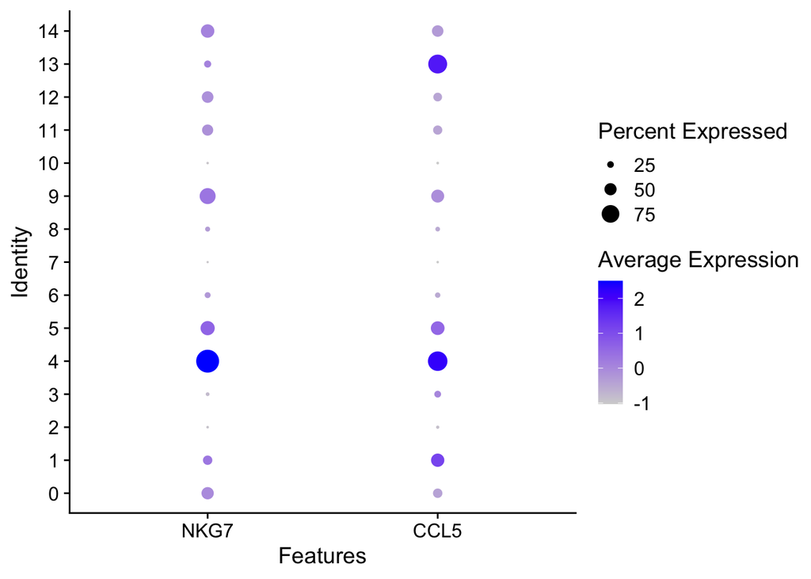

```r
DotPlot(allsamplesgood, features = mygenes)
```

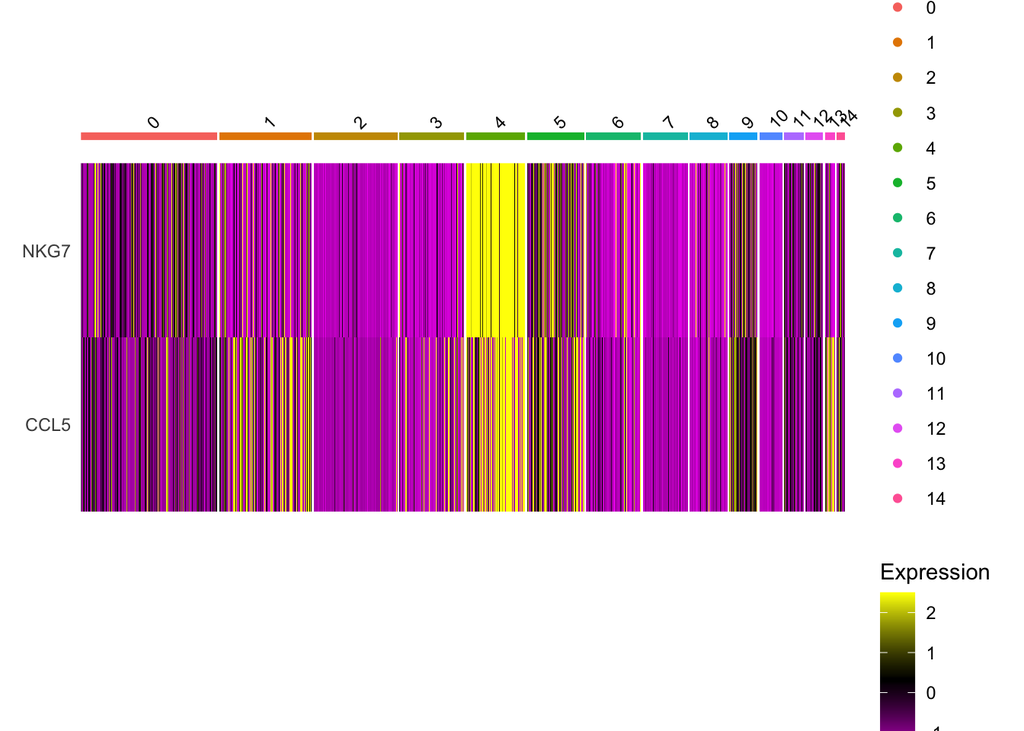

```r
DoHeatmap(subset(allsamplesgood), features = mygenes, size = 3)
```

## 7. Marker Identification Here we run findallmarkers to identify potential markers that are unique for each of the clusters.

```r
########################### Find all markers (about 80 minutes)
#markersall=FindAllMarkers(allsamplesgood)
head(markersall)
```

```
##         p_val avg_log2FC pct.1 pct.2 p_val_adj cluster    gene
## C1orf56     0  1.4630371 0.591 0.252         0       0 C1orf56
## IL1B        0  0.6066749 0.564 0.177         0       0    IL1B
## CXCL8       0  0.5038149 0.362 0.123         0       0   CXCL8
## CMSS1       0  0.4504773 0.731 0.433         0       0   CMSS1
## S100A8      0  0.2773159 0.593 0.193         0       0  S100A8
## S100A9      0  0.2416242 0.782 0.247         0       0  S100A9
```

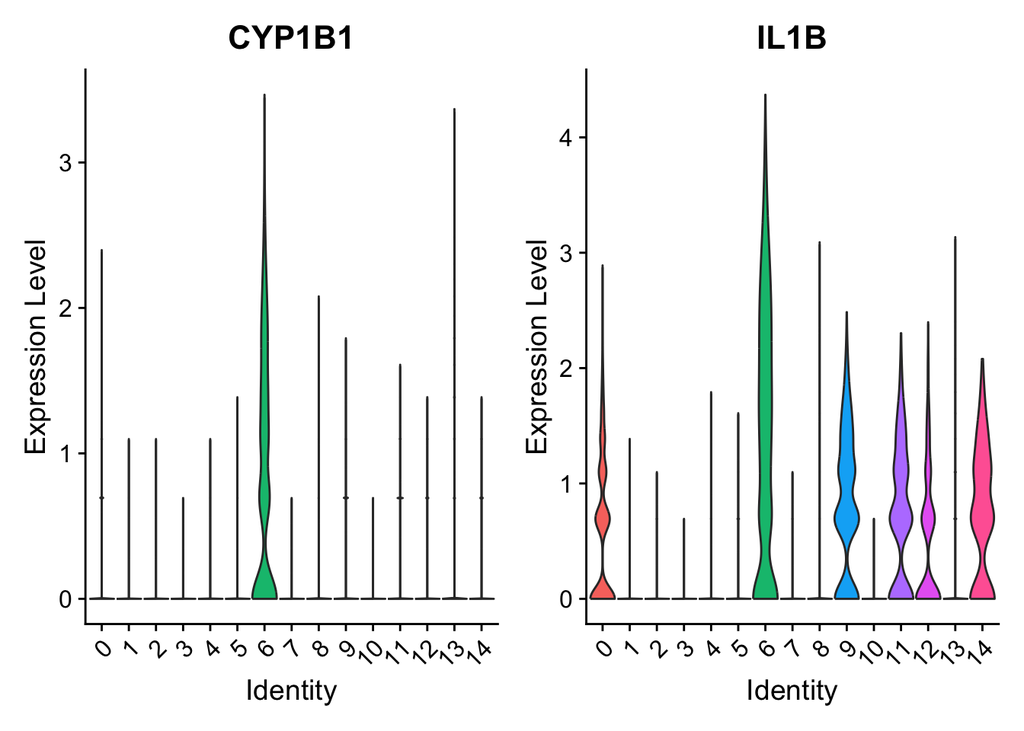

```r
# Save all markers as tab delimited file
write.table(markersall, file=paste(outputpath,"markersall.txt",sep=""),quote=F, row.names = FALSE, sep = ",")

# Plot selected markers
VlnPlot(allsamplesgood,features=c("CYP1B1","IL1B"), pt.size = 0)
```

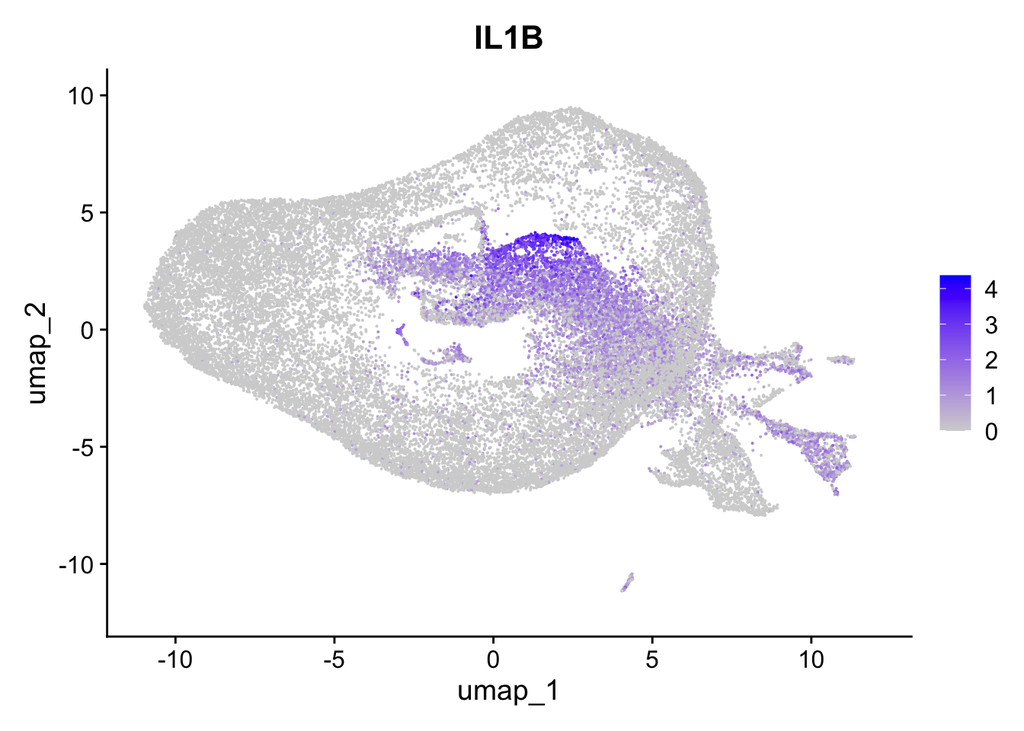

```r
FeaturePlot(allsamplesgood, features="IL1B")
```

```r
# Extract the top marker for each cluster
head(markersall)
```

```
##         p_val avg_log2FC pct.1 pct.2 p_val_adj cluster    gene
## C1orf56     0  1.4630371 0.591 0.252         0       0 C1orf56
## IL1B        0  0.6066749 0.564 0.177         0       0    IL1B
## CXCL8       0  0.5038149 0.362 0.123         0       0   CXCL8
## CMSS1       0  0.4504773 0.731 0.433         0       0   CMSS1
## S100A8      0  0.2773159 0.593 0.193         0       0  S100A8
## S100A9      0  0.2416242 0.782 0.247         0       0  S100A9
```

```r
markersall %>%
  group_by(cluster) %>%
  slice(1) %>%
  pull(gene) -> best.gene.per.cluster

best.gene.per.cluster
```

```
##  [1] "C1orf56"  "GZMK"     "RPS10"    "SLC35F1"  "FGFBP2"   "RPS3A"
##  [7] "TMEM176A" "LEF1"     "IGHD"     "C1orf56"  "KLF2"     "IGKC"
## [13] "IGLC1"    "SEPTIN5"  "IGHEP1"
```

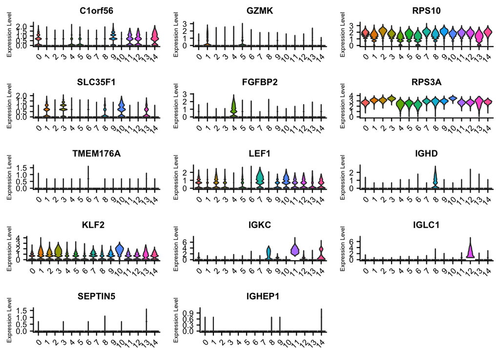

```r
# Store plot as ggplot list
vlnplot1<-VlnPlot(allsamplesgood,features=best.gene.per.cluster, pt.size = 0, combine = FALSE)

# Set properties for each plot in the list
p1 <- list()
for (i in seq_along(vlnplot1)){
  #Change x and y tick label font size.
  p1[[i]] = vlnplot1[[i]] +
    theme(legend.position = "none",
          axis.text.x = element_text(size = 8),
          axis.text.y = element_text(size = 8),
          axis.title.y = element_text(size = 6),
          axis.title.x = element_blank(),
          title = element_text(size=8))
}

# Plot all the plots in the list
plot_grid(plotlist = p1, ncol = 3)
```

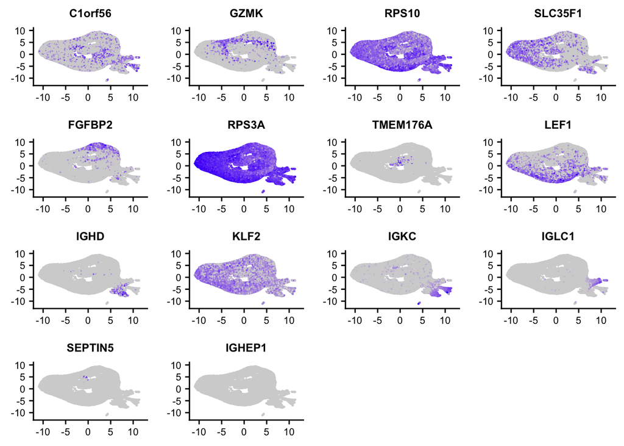

```r
# Save plot to file
vlnplot1=plot_grid(plotlist = p1, ncol = 3)
ggsave(paste(outputpath,"vlnplot-best-per-cluster.pdf",sep=""), plot = vlnplot1, width = 20, height = 15, units = "cm")

# Plot features in umap
fplot1<-FeaturePlot(allsamplesgood,features=best.gene.per.cluster, pt.size = 0, combine = FALSE)
p2 <- list()
for (i in seq_along(fplot1)){
  #Change x and y label font size.
  p2[[i]] = fplot1[[i]] +
    theme(legend.position = "none",
          axis.text.x = element_text(size = 8),
          axis.text.y = element_text(size = 8),
          axis.title.y = element_blank(),
          axis.title.x = element_blank(),
          title = element_text(size=8))
}

plot_grid(plotlist = p2, ncol = 4)
```

```r
fplot1=plot_grid(plotlist = p2, ncol = 4)
ggsave(paste(outputpath,"fplot-best-per-cluster.pdf",sep=""), plot = fplot1, width = 20, height = 15, units = "cm")
```

### 6.1. Annotation with SCassist

Here we use SCassist_analyze_and_annotate to analyze Top Markers, Predict Cell Types, and Optionally Annotate the Seurat Object.

```r
Idents(allsamplesgood) <- "SCT_snn_res.0.5"

# Run SCassist_analyze_and_annotate
sca_annotation <- SCassist_analyze_and_annotate(markersall, top_genes = 30, seurat_object_name = "allsamplesgood", api_key_file = api_key_file, llm_server="google")
```

```
## [1] "The output of Analyze and Annotate is saved as a tab delimited text if your current working directory. If you provided the name of the seurat object, the annotation is also added to that object in the SCassist_annotation column"
## [1] "SCassistant is analyzing markers to predict cell types for cluster : 0"
## [1] "SCassistant is analyzing markers to predict cell types for cluster : 1"
## [1] "SCassistant is analyzing markers to predict cell types for cluster : 2"
## [1] "SCassistant is analyzing markers to predict cell types for cluster : 3"
## [1] "SCassistant is analyzing markers to predict cell types for cluster : 4"
## [1] "SCassistant is analyzing markers to predict cell types for cluster : 5"
## [1] "SCassistant is analyzing markers to predict cell types for cluster : 6"
## [1] "SCassistant is analyzing markers to predict cell types for cluster : 7"
## [1] "SCassistant is analyzing markers to predict cell types for cluster : 8"
## [1] "SCassistant is analyzing markers to predict cell types for cluster : 9"
## [1] "SCassistant is analyzing markers to predict cell types for cluster : 10"
## [1] "SCassistant is analyzing markers to predict cell types for cluster : 11"
## [1] "SCassistant is analyzing markers to predict cell types for cluster : 12"
## [1] "SCassistant is analyzing markers to predict cell types for cluster : 13"
```

[output cut: 33 more lines]

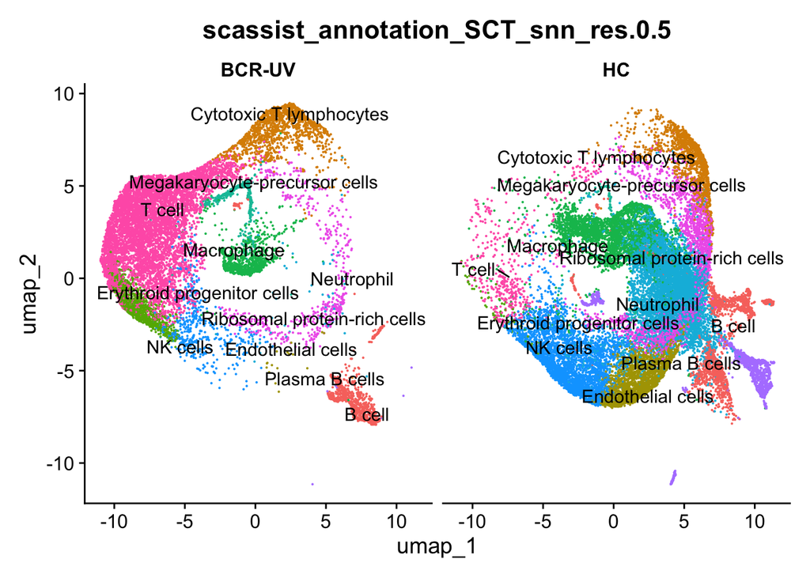

```r
allsamplesgood = sca_annotation

# create and save umap with labels
an0=DimPlot(allsamplesgood, reduction = "umap", label = TRUE, repel = TRUE, group.by = 'scassist_annotation_SCT_snn_res.0.5', split.by = "type")

an0a=an0+theme(legend.position="none")
an0a
```

```r
ggsave(paste(outputpath,"umap-with-sctype.pdf",sep=""),plot=an0a, width = 50, height = 30, units = "cm")
```

## 8. Differential Expression

Here we perform differential expression analysis between HC vs BCR-UV within the NK cell populations, to identify genes that might be contributing to different subpopulations.

```r
########################### tables
# Proportion and counts of cells in clusters and groups
# Change identity to 0.3 cluster resolution
Idents(allsamplesgood) <- "scassist_annotation_SCT_snn_res.0.5"
prop.table(table(Idents(allsamplesgood)))
```

```
##
##                    Neutrophil                      NK cells
##                    0.18480281                    0.11402179
##       Cytotoxic T lymphocytes                Plasma B cells
##                    0.08007550                    0.03729230
##                    Macrophage             Endothelial cells
##                    0.11290645                    0.06137215
##                        B cell    Erythroid progenitor cells
##                    0.07438442                    0.03111505
##                        T cell Megakaryocyte-precursor cells
##                    0.21288644                    0.01352704
##  Ribosomal protein-rich cells
##                    0.07761604
```

```r
table(Idents(allsamplesgood))
```

```
##
##                    Neutrophil                      NK cells
##                          6462                          3987
##       Cytotoxic T lymphocytes                Plasma B cells
##                          2800                          1304
##                    Macrophage             Endothelial cells
##                          3948                          2146
##                        B cell    Erythroid progenitor cells
##                          2601                          1088
##                        T cell Megakaryocyte-precursor cells
##                          7444                           473
##  Ribosomal protein-rich cells
##                          2714
```

```r
# Current identity levels
levels(allsamplesgood)
```

```
##  [1] "Neutrophil"                    "NK cells"
##  [3] "Cytotoxic T lymphocytes"       "Plasma B cells"
##  [5] "Macrophage"                    "Endothelial cells"
##  [7] "B cell"                        "Erythroid progenitor cells"
##  [9] "T cell"                        "Megakaryocyte-precursor cells"
## [11] "Ribosomal protein-rich cells"
```

```r
head(Idents(allsamplesgood))
```

```
## AAACCCACAAGTCATC-NS3R189BTS AAACCCACACTGGAAG-NS3R189BTS
##                  Neutrophil                    NK cells
## AAACCCACAGCACACC-NS3R189BTS AAACCCACAGGAGGAG-NS3R189BTS
##                  Neutrophil     Cytotoxic T lymphocytes
## AAACCCACATGACGTT-NS3R189BTS AAACCCAGTAGTTACC-NS3R189BTS
##              Plasma B cells                  Macrophage
## 11 Levels: Neutrophil NK cells Cytotoxic T lymphocytes ... Ribosomal protein-rich cells
```

```r
# Take all cells in cluster 'Natural Killer cells', and find markers that separate 'HC' and 'BCR-UV' that are in the 'type' column. subset.ident would be the default identity of clusters
markersingroup <- FindMarkers(allsamplesgood, ident.1 = "HC", ident.2 = "BCR-UV", group.by = 'type', subset.ident = "NK cells")

#markersingroup <- FindMarkers(allsamplesgood, ident.1 = "HC", ident.2 = "BCR-UV", group.by = 'type', subset.ident = "2")

head(markersingroup)
```

```
##                 p_val avg_log2FC pct.1 pct.2     p_val_adj
## SLC35F1  0.000000e+00  -5.482623 0.018 0.572  0.000000e+00
## IFITM1   0.000000e+00  -5.254630 0.028 0.599  0.000000e+00
## RPS26   4.289374e-289  -3.971019 0.703 1.000 1.072043e-284
## ARL17B  5.752066e-224  -6.234951 0.006 0.324 1.437614e-219
## HLA-B   1.671281e-223  -1.663662 0.968 1.000 4.177031e-219
## MALAT1  1.257242e-220  -1.282043 1.000 1.000 3.142226e-216
```

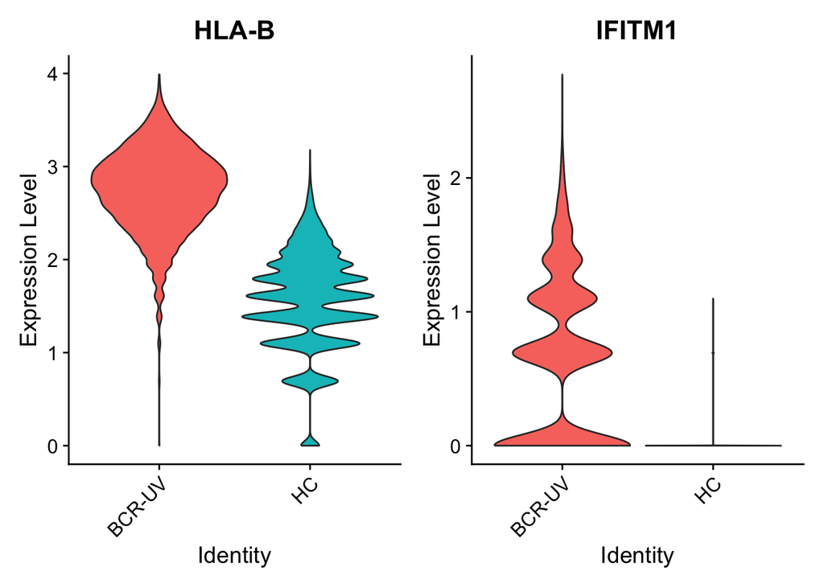

```r
# Save markers
write.table(markersingroup, file="markersingroup.txt", quote=F, row.names = FALSE, sep = "\t")
VlnPlot(allsamplesgood,features=c("HLA-B","IFITM1"), group.by = "type", pt.size = 0)
```

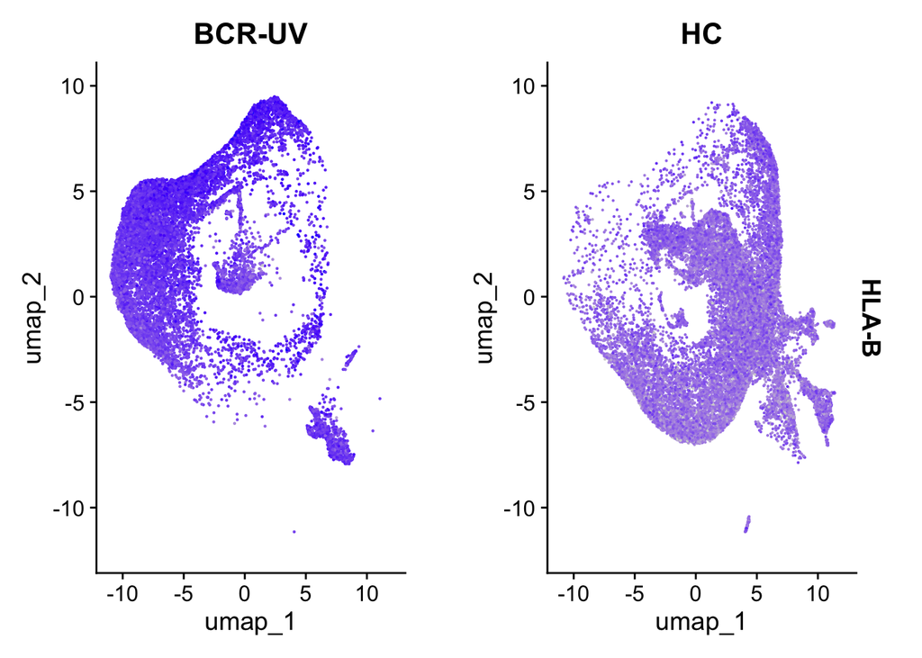

```r
FeaturePlot(allsamplesgood, features=c("HLA-B"), split.by = "type")
```

```r
table(allsamplesgood$type)
```

```
##
## BCR-UV     HC
##  12772  22195
```

### 8.1. Pathway Enrichment Analysis

Here we run the pathway enrichment analysis using SCassist_analyze_enrichment on the list of differentially expressed genes from the two NK populations found in HC and BCR-UV. SCassist does not perform enrichment analysis, but takes the clusterprofiler output for KEGG pathway enrichment and tries to understand how the identified pathways could represent the system.

```r
########################### Marker genes between groups

# Run enrichment analysis using 'human' database, with experimental_design, pvalue and log2FC cut off values
api_key_file="/singlecellassistant/api_keys.txt"

scassist_pathway_summary <- SCassist_analyze_enrichment(markers=markersingroup,experimental_design = experimental_design, pvalue=0.05, log2FC=1, api_key_file=api_key_file, llm_server = "google")
```

```
##
## The KEGG analysis is presented below.
## -------------------------------------------
##
## The ClusterProfiler KEGG pathways result is saved as a text file in the current working directory.
##
## The list of significantly enriched KEGG pathways is also saved as a text file in the current working directory.
##
## KEGG Enrichment Insights:
## ## 1. Significant Pathways:
##
## The KEGG pathway enrichment analysis reveals a significant enrichment of pathways related to cancer, immune response, and cellular processes in the PBMCs of the uveitis patient compared to the healthy control.  Several pathways associated with cancer development and progression are enriched, incl…
##
## Furthermore, the enrichment of pathways related to immune response, such as "Allograft rejection", "Asthma", "Autoimmune thyroid disease", "Graft-versus-host disease", "Inflammatory bowel disease", "Rheumatoid arthritis", "Antigen processing and presentation", "B cell receptor signaling pathway",…
##
## ## 2. Regulators:
##
## The list of enriched pathways includes several transcription factors, such as JUN, FOS, NFKBIA, TP53, and STAT1, which are known to play crucial roles in regulating gene expression and cellular processes. These transcription factors may be involved in the dysregulation of pathways associated with…
##
## ## 3. Key Genes or Potential Targets:
##
## Several genes from the enriched pathways could be important targets for further investigation in the context of uveitis. For example, genes involved in the "Central carbon metabolism in cancer" pathway, such as SLC7A5, GLS, and PIK3R1, could be potential targets for therapeutic intervention.  Gen…
##
## The GO analysis is provided below.
## ----------------------------------------
##
## The ClusterProfiler GO enrichment result is saved as a text file in the current working directory.
##
## The list of significantly enriched GO terms is also saved as a text file in the current working directory.
##
## GO Enrichment Insights:
## ## 1. Significant Concepts:
##
## The GO enrichment analysis reveals a strong focus on immune system processes, particularly B cell and T cell activation, differentiation, and mediated immunity.  Several GO terms related to DNA metabolism and repair are also enriched, suggesting alterations in genomic stability and response to DN…
##
## The enrichment of GO terms related to RNA processing, particularly splicing and methylation, suggests potential dysregulation in gene expression and protein synthesis.  Furthermore, the enrichment of GO terms related to organelle organization and transport, particularly those involving the Golgi …
##
## ## 2. Regulators:
##
## Several transcription factors are present in the enriched GO terms, potentially playing a role in the observed changes in PBMCs.  For example, **KLF2, KLF4, KLF6, and ZBTB1** are involved in regulating gene expression and cell differentiation, potentially contributing to the observed differences …
```

[output cut: 20 more lines]

```
## * **RNA Processing:**  Enrichment of GO terms related to RNA processing, particularly splicing and methylation, suggests potential dysregulation in gene expression and protein synthesis.
## * **Organelle Organization and Transport:**  Enrichment of GO terms related to organelle organization and transport, particularly those involving the Golgi apparatus, endosome, and lysosome, suggests alterations in cellular trafficking and protein processing.
##
## **Key Regulators:**
##
## * **Transcription Factors:**  Several transcription factors are identified as potential regulators of the observed changes in PBMCs. These include JUN, FOS, NFKBIA, TP53, STAT1, KLF2, KLF4, KLF6, ZBTB1, FOXP3, IRF1, and IRF8. These factors are known to play crucial roles in regulating gene expres…
##
## **Key Genes and Potential Targets:**
##
## * **Cancer-Related Genes:**  Genes involved in the "Central carbon metabolism in cancer" pathway, such as SLC7A5, GLS, and PIK3R1, and genes involved in the "PD-L1 expression and PD-1 checkpoint pathway in cancer", such as PIK3R1, CD4, and STAT1, could be potential targets for therapeutic interve…
## * **Apoptosis-Related Genes:**  Genes involved in the "Apoptosis" pathway, such as CASP8, BAX, and CASP3, could be investigated for their role in cell death and potential therapeutic targets.
## * **Inflammation-Related Genes:**  Genes involved in the "TNF signaling pathway", such as TNF, NFKBIA, and CHUK, could be investigated for their role in inflammation and potential therapeutic targets.
## * **Immune-Related Genes:**  Genes like TNFAIP3, FOXP3, IRF1, IRF8, ATG5, CTLA4, CD40, NLRP3, and MYD88 are identified as potential targets due to their roles in regulating immune responses, cell differentiation, and inflammation.
##
## **Overall, this analysis highlights the complex interplay between cancer, immune response, and cellular processes in the pathogenesis of uveitis. The identified pathways, regulators, and genes provide valuable insights for further investigation and potential therapeutic targets for this disease.*…
```

```r
# Network style summary of the enrichment analysis
scassist_pathway_summary
```

[interactive chart not shown]

## 9. Proportion test

```r
# Sample proportion table
# Proportion and counts of cells in individual samples

# Proportion test
# assign sample group
allsamplesgood$sample=ifelse(grepl("HC",allsamplesgood$type), "HC", ifelse(grepl("UV",allsamplesgood$type), "UV", ""))

prop.table(table(Idents(allsamplesgood), allsamplesgood$scassist_annotation_SCT_snn_res.0.5))
```

```
##
##                                     B cell Cytotoxic T lymphocytes
##   Neutrophil                    0.00000000              0.00000000
##   NK cells                      0.00000000              0.00000000
##   Cytotoxic T lymphocytes       0.00000000              0.08007550
##   Plasma B cells                0.00000000              0.00000000
##   Macrophage                    0.00000000              0.00000000
##   Endothelial cells             0.00000000              0.00000000
##   B cell                        0.07438442              0.00000000
##   Erythroid progenitor cells    0.00000000              0.00000000
##   T cell                        0.00000000              0.00000000
##   Megakaryocyte-precursor cells 0.00000000              0.00000000
##   Ribosomal protein-rich cells  0.00000000              0.00000000
##
##                                 Endothelial cells Erythroid progenitor cells
##   Neutrophil                           0.00000000                 0.00000000
##   NK cells                             0.00000000                 0.00000000
##   Cytotoxic T lymphocytes              0.00000000                 0.00000000
##   Plasma B cells                       0.00000000                 0.00000000
##   Macrophage                           0.00000000                 0.00000000
##   Endothelial cells                    0.06137215                 0.00000000
##   B cell                               0.00000000                 0.00000000
##   Erythroid progenitor cells           0.00000000                 0.03111505
##   T cell                               0.00000000                 0.00000000
##   Megakaryocyte-precursor cells        0.00000000                 0.00000000
##   Ribosomal protein-rich cells         0.00000000                 0.00000000
##
##                                 Macrophage Megakaryocyte-precursor cells
##   Neutrophil                    0.00000000                    0.00000000
##   NK cells                      0.00000000                    0.00000000
##   Cytotoxic T lymphocytes       0.00000000                    0.00000000
##   Plasma B cells                0.00000000                    0.00000000
##   Macrophage                    0.11290645                    0.00000000
##   Endothelial cells             0.00000000                    0.00000000
##   B cell                        0.00000000                    0.00000000
##   Erythroid progenitor cells    0.00000000                    0.00000000
##   T cell                        0.00000000                    0.00000000
##   Megakaryocyte-precursor cells 0.00000000                    0.01352704
##   Ribosomal protein-rich cells  0.00000000                    0.00000000
##
```

[output cut: 10 more lines]

```
##   Megakaryocyte-precursor cells 0.00000000 0.00000000     0.00000000
##   Ribosomal protein-rich cells  0.00000000 0.00000000     0.00000000
##
##                                 Ribosomal protein-rich cells     T cell
##   Neutrophil                                      0.00000000 0.00000000
##   NK cells                                        0.00000000 0.00000000
##   Cytotoxic T lymphocytes                         0.00000000 0.00000000
##   Plasma B cells                                  0.00000000 0.00000000
##   Macrophage                                      0.00000000 0.00000000
##   Endothelial cells                               0.00000000 0.00000000
##   B cell                                          0.00000000 0.00000000
##   Erythroid progenitor cells                      0.00000000 0.00000000
##   T cell                                          0.00000000 0.21288644
##   Megakaryocyte-precursor cells                   0.00000000 0.00000000
##   Ribosomal protein-rich cells                    0.07761604 0.00000000
```

```r
table(Idents(allsamplesgood), allsamplesgood$scassist_annotation_SCT_snn_res.0.5)
```

```
##
##                                 B cell Cytotoxic T lymphocytes
##   Neutrophil                         0                       0
##   NK cells                           0                       0
##   Cytotoxic T lymphocytes            0                    2800
##   Plasma B cells                     0                       0
##   Macrophage                         0                       0
##   Endothelial cells                  0                       0
##   B cell                          2601                       0
##   Erythroid progenitor cells         0                       0
##   T cell                             0                       0
##   Megakaryocyte-precursor cells      0                       0
##   Ribosomal protein-rich cells       0                       0
##
##                                 Endothelial cells Erythroid progenitor cells
##   Neutrophil                                    0                          0
##   NK cells                                      0                          0
##   Cytotoxic T lymphocytes                       0                          0
##   Plasma B cells                                0                          0
##   Macrophage                                    0                          0
##   Endothelial cells                          2146                          0
##   B cell                                        0                          0
##   Erythroid progenitor cells                    0                       1088
##   T cell                                        0                          0
##   Megakaryocyte-precursor cells                 0                          0
##   Ribosomal protein-rich cells                  0                          0
##
##                                 Macrophage Megakaryocyte-precursor cells
##   Neutrophil                             0                             0
##   NK cells                               0                             0
##   Cytotoxic T lymphocytes                0                             0
##   Plasma B cells                         0                             0
##   Macrophage                          3948                             0
##   Endothelial cells                      0                             0
##   B cell                                 0                             0
##   Erythroid progenitor cells             0                             0
##   T cell                                 0                             0
##   Megakaryocyte-precursor cells          0                           473
##   Ribosomal protein-rich cells           0                             0
##
```

[output cut: 10 more lines]

```
##   Megakaryocyte-precursor cells          0        0              0
##   Ribosomal protein-rich cells           0        0              0
##
##                                 Ribosomal protein-rich cells T cell
##   Neutrophil                                               0      0
##   NK cells                                                 0      0
##   Cytotoxic T lymphocytes                                  0      0
##   Plasma B cells                                           0      0
##   Macrophage                                               0      0
##   Endothelial cells                                        0      0
##   B cell                                                   0      0
##   Erythroid progenitor cells                               0      0
##   T cell                                                   0   7444
##   Megakaryocyte-precursor cells                            0      0
##   Ribosomal protein-rich cells                          2714      0
```

```r
# Save tables
write.table(prop.table(table(Idents(allsamplesgood), allsamplesgood$scassist_annotation_SCT_snn_res.0.5)), file=paste(outputpath,"cluster-proportions.txt",sep=""), quote=F, sep = "\t")
write.table(table(Idents(allsamplesgood), allsamplesgood$scassist_annotation_SCT_snn_res.0.5), file=paste(outputpath,"cluster-counts.txt",sep=""), quote=F, sep = "\t")

# Run permutation test
prop_test <- sc_utils(allsamplesgood)
prop_test <- permutation_test(
  prop_test, cluster_identity = "scassist_annotation_SCT_snn_res.0.5",
  sample_1 = "HC", sample_2 = "BCR-UV",
  sample_identity = "type",
  n_permutations = 10000
)

plot_data=prop_test@results$permutation
plot_data
```

```
## Key: <clusters>
##                          clusters       BCR-UV          HC obs_log2FD
##                            <char>        <num>       <num>      <num>
##  1:                        B cell 0.0703883495 0.076683938 -0.1235878
##  2:       Cytotoxic T lymphocytes 0.1148606326 0.060058572  0.9354423
##  3:             Endothelial cells 0.0013310366 0.095922505 -6.1712471
##  4:    Erythroid progenitor cells 0.0798621986 0.003063753  4.7041408
##  5:                    Macrophage 0.0728155340 0.135976571 -0.9010399
##  6: Megakaryocyte-precursor cells 0.0304572502 0.003784636  3.0085592
##  7:                      NK cells 0.0376605074 0.157963505 -2.0684669
##  8:                    Neutrophil 0.0045411838 0.288533453 -5.9895263
##  9:                Plasma B cells 0.0006263702 0.058391530 -6.5425998
## 10:  Ribosomal protein-rich cells 0.0407923583 0.098806037 -1.2763003
## 11:                        T cell 0.5466645788 0.020815499  4.7149259
##           pval         FDR boot_mean_log2FD boot_CI_2.5 boot_CI_97.5
##          <num>       <num>            <num>       <num>        <num>
##  1: 0.01649835 0.016498350       -0.1238388  -0.2394087  -0.01032646
##  2: 0.00009999 0.000109989        0.9348009   0.8319372   1.03505340
##  3: 0.00009999 0.000109989       -6.2105337  -6.9643176  -5.59436282
##  4: 0.00009999 0.000109989        4.7162778   4.3735695   5.08265247
##  5: 0.00009999 0.000109989       -0.9011725  -1.0030494  -0.80228322
##  6: 0.00009999 0.000109989        3.0143311   2.6851774   3.36799889
##  7: 0.00009999 0.000109989       -2.0703577  -2.2071623  -1.94068825
##  8: 0.00009999 0.000109989       -6.0002551  -6.4033202  -5.64613015
##  9: 0.00009999 0.000109989       -6.6520279  -7.9742392  -5.73078518
## 10: 0.00009999 0.000109989       -1.2777645  -1.4138475  -1.14641911
## 11: 0.00009999 0.000109989        4.7170552   4.5868278   4.85229708
```

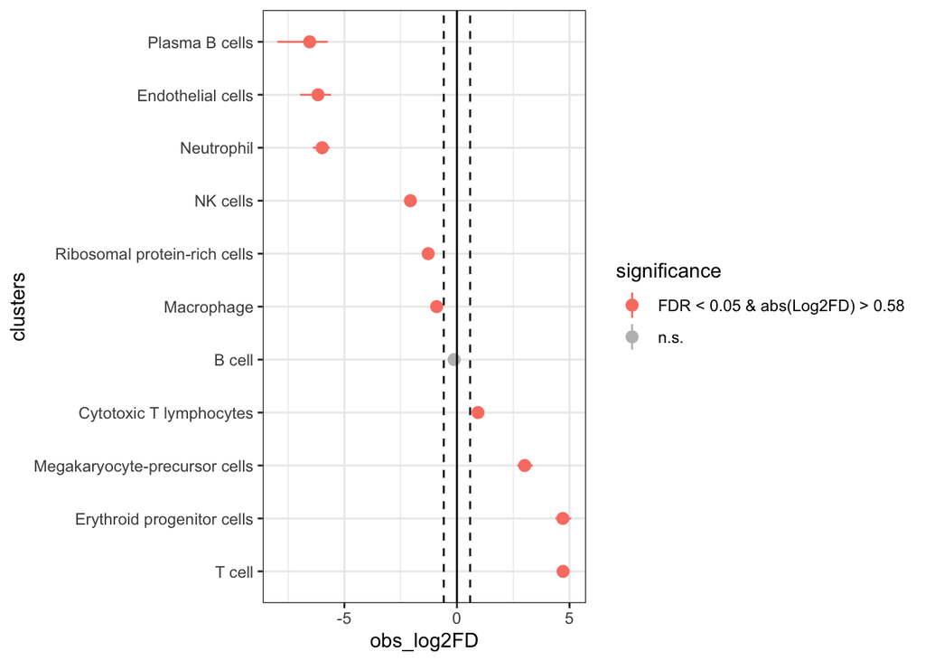

```r
FDR_threshold = 0.05
log2FD_threshold = log2(1.5)
order_clusters = TRUE

plot_data[, significance := ifelse(
  FDR < FDR_threshold & abs(obs_log2FD) > log2FD_threshold,
  paste("FDR <", FDR_threshold, "& abs(Log2FD) >", round(log2FD_threshold, 2)),
  "n.s."
)]

plot_data[, significance := factor(significance, levels = c(
  paste("FDR <", FDR_threshold, "& abs(Log2FD) >", round(log2FD_threshold, 2)),
  "n.s."
))]

#library(tidyverse)
## Order the clusters by observed log2FD if requested.
if (order_clusters) {
  plot_data[, clusters := fct_reorder(factor(clusters), dplyr::desc(obs_log2FD))]
}

## Plot the results.
p <- ggplot(plot_data, aes(x = clusters, y = obs_log2FD)) +
  geom_pointrange(aes(ymin = boot_CI_2.5, ymax = boot_CI_97.5, color = significance)) +
  theme_bw() +
  geom_hline(yintercept = log2FD_threshold, lty = 2) +
  geom_hline(yintercept = -log2FD_threshold, lty = 2) +
  geom_hline(yintercept = 0) +
  scale_color_manual(values = c("salmon", "grey")) +
  coord_flip()

p
```

```r
ggsave(paste(outputpath,"cluster_proportion_test_labelled.pdf",sep=""), plot=p)
```

## 10. Save

```r
save.image(file=paste(outputpath,"bcruv_G_new.RData",sep=""))
```